# ENS 623 - Spring 2020 - Problem Set 8

**Please submit this homework as an R Markdown (Rmd) file AND a Word file (docx).** See the introduction to [Problem Set 1](http://mlammens.github.io/ENS-623-Research-Stats/problem_sets/Problem-set-1.html) if you need more information about the Rmd format.

#### File name

Your file should use the following naming scheme

**`[last name]_ENS623_SP20_PS8.Rmd`**

For example,

`Lammens_ENS623_SP20_PS8.Rmd`

# A comparison of metabolic rates of northern fulmars (sea-bird)

[Furness and Bryant (1996)](https://esajournals.onlinelibrary.wiley.com/doi/abs/10.2307/2265587) measured the metabolic rates of male and female breeding northern fulmars, and tested if there were any observable differences in these rates.

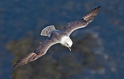

Attribution: Northern-Fulmar2.jpg: Andreas Treptederivative work: Bogbumper / CC BY-SA [(https://creativecommons.org/licenses/by-sa/2.5)](https://creativecommons.org/licenses/by-sa/2.5)

Get the data and have a look

```r
fulmars <- read.csv(file = "https://mlammens.github.io/ENS-623-Research-Stats/data/Logan_Examples/Chapter6/Data/furness.csv")
fulmars
```

```
##             SEX METRATE BODYMASS
## 1  Male          2950.0      875
## 2  Female        1956.1      635
## 3  Male          2308.7      765
## 4  Male          2135.6      780
## 5  Male          1945.6      790
## 6  Female        1490.5      635
## 7  Female        1361.3      668
## 8  Female        1086.5      640
## 9  Female        1091.0      645
## 10 Male          1195.5      788
## 11 Female         727.7      635
## 12 Male           843.3      855
## 13 Male           525.8      860
## 14 Male           605.7     1005
```

```r
summary(fulmars)
```

```
##            SEX       METRATE          BODYMASS
##  Female      :6   Min.   : 525.8   Min.   : 635.0
##  Male        :8   1st Qu.: 904.1   1st Qu.: 641.2
##                   Median :1278.4   Median : 772.5
##                   Mean   :1444.5   Mean   : 755.4
##                   3rd Qu.:1953.5   3rd Qu.: 838.8
##                   Max.   :2950.0   Max.   :1005.0
```

# Problem 1

Make a box plot showing a comparison of metabolic rate (`METRATE` in this data set) and the sex of northern fulmars.

# Problem 2

Calculate a *t* statistic, using the formulas presented in [Lecture 9](http://mlammens.github.io/ENS-623-Research-Stats/lectures/Lecture-9.html) and following the example related to fecundity of intertidal gastropods. Once you have the *t* statistic, calculate the probability that the samples of metabolic rates for male and female northern fulmars come from the same population.

**Use this probability value to make a statement about whether you would accept or reject your null hypothesis.**

# Problem 3

Use the `t.test` function to verify that your answers for Problem 2 are correct. **Hint:** for this to work properly you will need to add the argument `var.equal = TRUE` to the `t.test` function call.

# Problem 4

Go back to Problem 1 and look at the box plots. You should notice that the variances (standard deviations) of the two groups are quite different from each other. This is a violation of one of the assumptions of the *t* test. One way to address this is to use the **Welch’s *t* test**. R will use Welch’s *t* test by default if the variances are not equal, but you can make sure it does by setting `var.equal = FALSE`.

**Compare the results of Problem 3 and Problem 4. How do they differ?**